# Analysis of Crypto Currencies

Quentin Picard

October 7, 2017

### Introduction

The goal of this document is to provide an overview of crypto currencies, or “coins”. The Bitcoin white paper was written in late 2008 but today many more currencies than Bitcoin exist. Some of the questions we will answer include: what are the coins relative importance (by total value)? How have prices behaved in the last few years? How would basic investing strategies have performed during that timeframe?

### Data

The data file studied here contains OHLC (Open-High-Low-Close) data for about 1100 crypto currencies during the last 5 years. The data was scrapped from https://coinmarketcap.com/ by [Jvent](https://www.kaggle.com/jessevent) and uploaded to Kaggle.

Source file: [link](https://www.kaggle.com/jessevent/all-crypto-currencies)

Here is a sample of the data:

```
##         date    open    high     low   close     volume      market symbol
## 1 2017-09-28 4197.13 4279.31 4109.70 4174.73 1712320000 69633200000    BTC
## 2 2017-09-27 3892.94 4210.05 3884.82 4200.67 1686880000 64579200000    BTC
## 3 2017-09-26 3928.41 3969.89 3869.90 3892.35 1043740000 65161000000    BTC
## 4 2017-09-25 3681.58 3950.25 3681.58 3926.07 1374210000 61061100000    BTC
## 5 2017-09-24 3796.15 3796.15 3666.90 3682.84  768015000 62954300000    BTC
##      coin variance volatility
## 1 Bitcoin    0.005      0.041
## 2 Bitcoin   -0.073      0.077
## 3 Bitcoin    0.009      0.026
## 4 Bitcoin   -0.062      0.068
## 5 Bitcoin    0.031      0.035
```

The file contains 1129 different coins. Here are the first 20 in alphabetical order:

```
## $$$ (Money)
## 1337 (1337)
## 1CR (1CRedit)
## 1ST (FirstBlood)
## 20 (020LondonCoin)
## 2GIVE (2GIVE)
## 300 (300)
## 42 (42-coin)
## 4CHN (ChanCoin)
## 611 (SixEleven)
## 808 (808Coin)
## 888 (OctoCoin)
## 8BIT (8Bit)
## 9COIN (9COIN)
## ABC (Alphabit)
## ABC (Asset)
## ABN (Abncoin)
## ABY (ArtByte)
## AC (AsiaCoin)
## ACC (AdCoin)
```

### Coins creation

The following graph shows the constant rise of reported coins. We observe some volatility in the number of new coins in last few months. One factor was China’s decision to ban initial coin offerings (ICOs) on September, 4th. Today the pace of new ICOs globally is still strong.

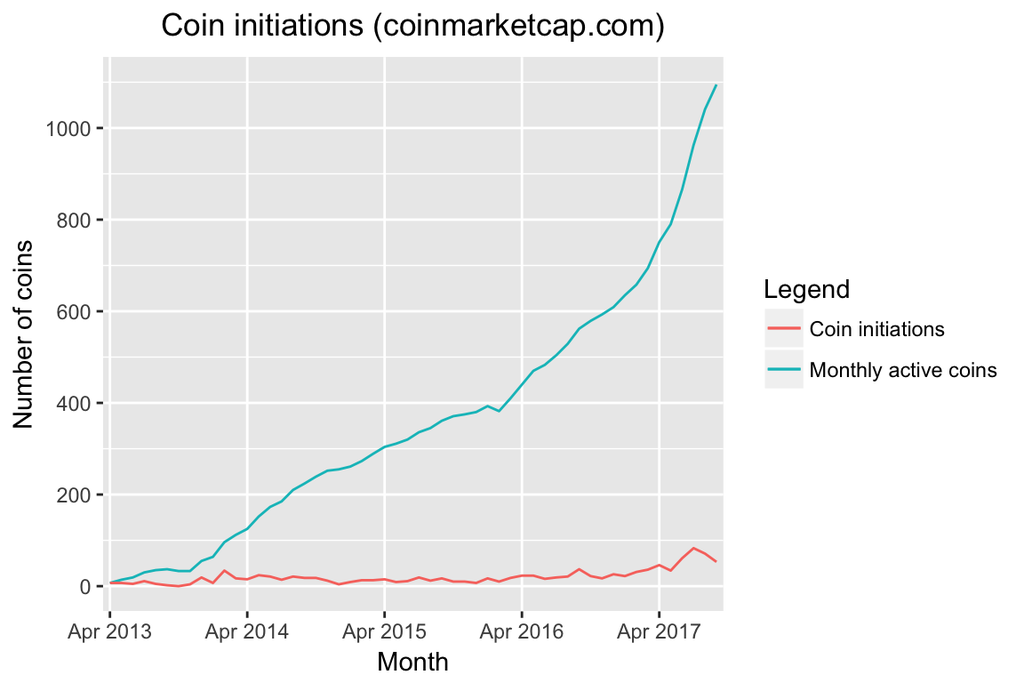

### Market Capitalisation Distribution

Looking at the distribution of coin market caps, we observe a large skew towards smaller valuations. In fact 230 (20.37%) of coins have no market capitalisation as of September 28th, 2017 (the market cap reported by the website is $0). 678 (60.05%) have a market cap below $1 million.

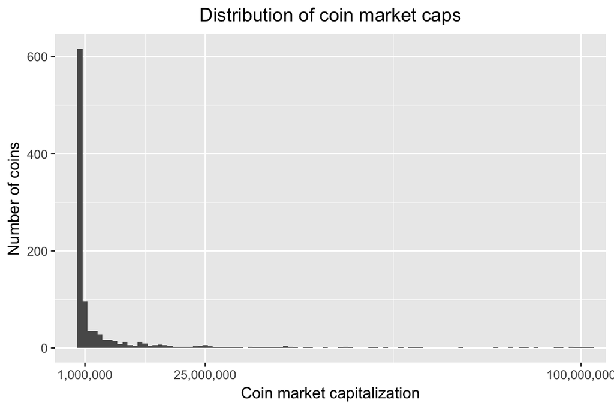

### Coins Market Cap graph

Since a few coins were clearly dominant we will now represent their relative share of the overall crypto currency pie as measured by market cap. This graph shows a key trend in the past year: the emergence of new coins such as Ethereum and Ripple (22% and 5% of total market cap respectively) and a reduction of the Bitcoin total share from 90% to 50%.

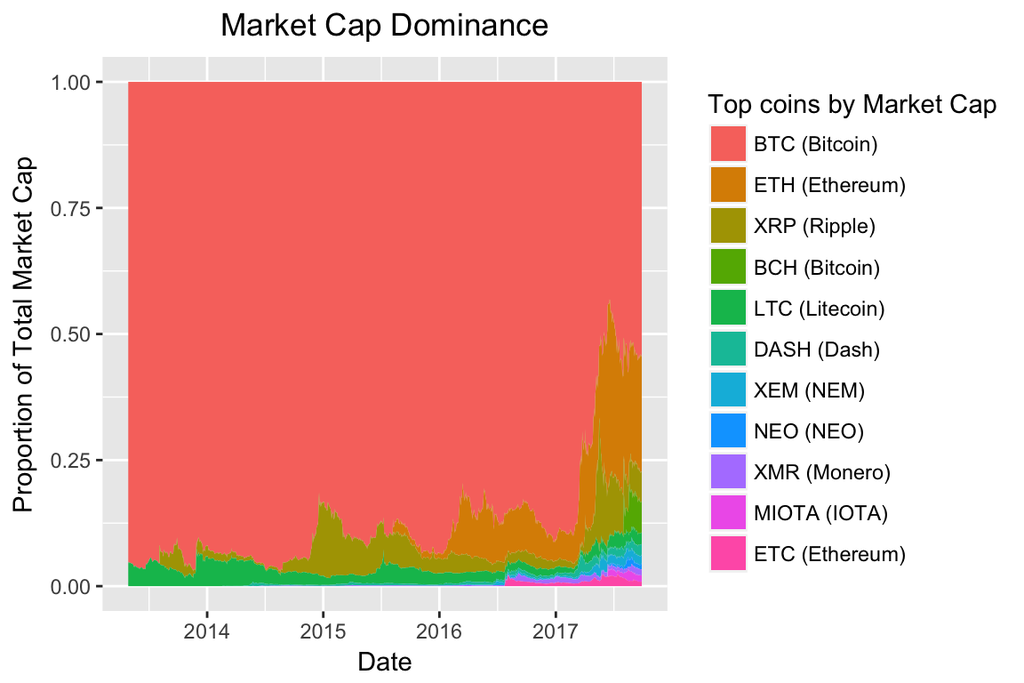

### Return distribution

In the graph below, all coins prices were normalized to start trade at $1 on April 28th, 2013. Plotting prices or log prices for all coins isn’t a viable option here. The coins should be clustered so that it’s possible to read the data. This analysis is outside the scope of this document.

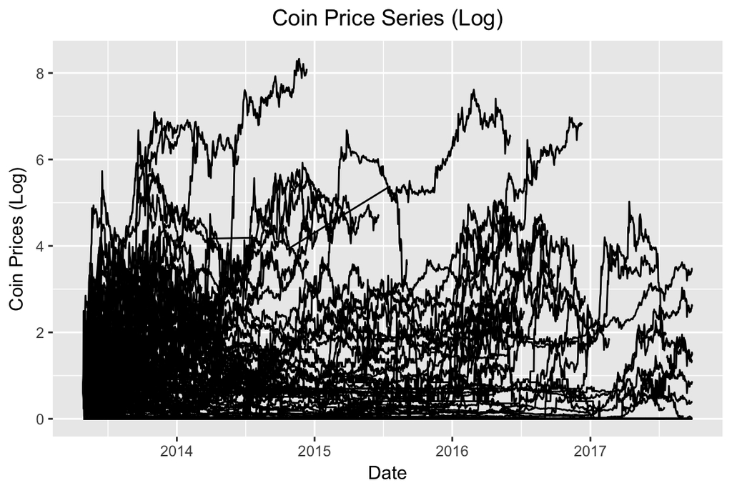

### Trading Strategies

In order to better understand the behavior of these coins, I implemented a basic dollar averaging trading strategy. Starting 5 years ago when data is available, everytime the daily trading volume passes a certain threshold ($100,000 to start) for a given coin, I buy $1 of it and hold it forever. The composition of the portfolio on the last day where data is available (September 28th, 2017) is shown below:

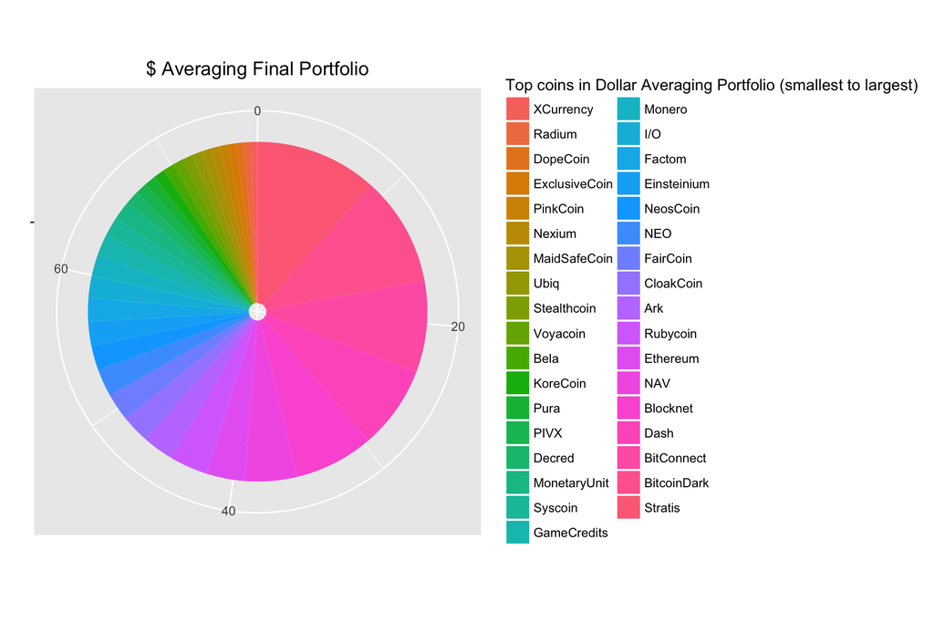

Conclusion: 50% of the portfolio is made of just 6 coins. Stratis, the biggest position, went up 200,000 times. The next step would be to check if those coins indeed could have been purchased at the initial ‘low’ prices reported on Coinmarketcap.com. Historical exchange data would be needed for this.

The value of the portfolio over time (net of the cash investment represented in red) is plotted below:

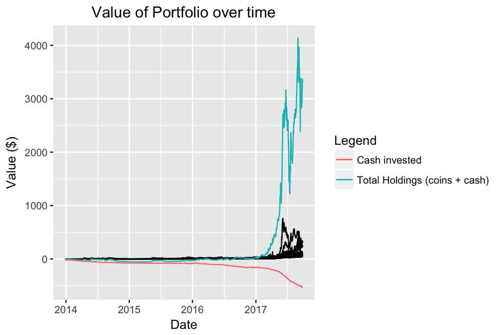

Finally I plotted the value of the final portfolio as a function of the volume threshold at which I would buy each coin. The gains get exponentially higher as the threshold diminishes. Meaning that if I buy each coin “right away” -say when the daily volume is only above $1000- then some of the coins will experience a meteoric rise and the portfolio will grow more during the holding period. Same conclusion here: we would need to check with exchange data if these coins were truly available at such small volumes. At the very least we can conclude that this trading strategy would only be available to small players.

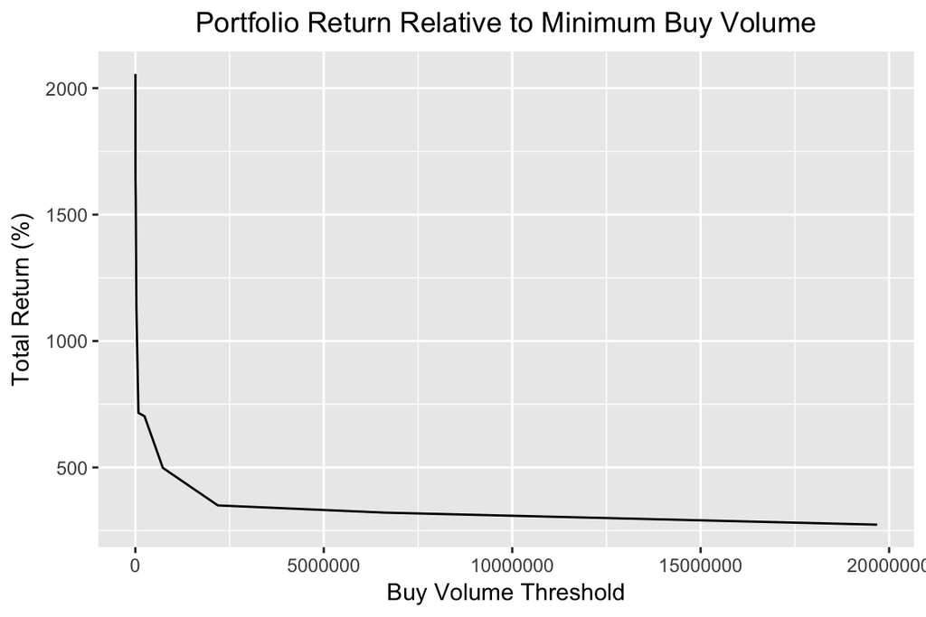

### Additional studies

In response to comments from the author of the data file, I created 2 more graphs. The first one looked into the alleged strong returns of Bitcoin in the first days of the month. This is not supported by the data which shows no relationship. Note that I focused on the last 12 months for this analysis as there was limited activity in the previous 4 years.

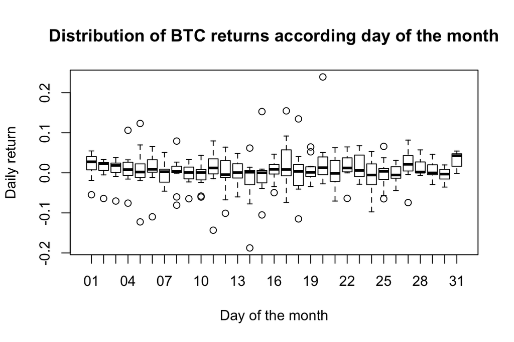

The second shows the returns of a coins index (with ‘traditional’ market cap weights) in relation to Bitcoin returns. Supposedly Bitcoin price surges were causing alternative coin holders to sell their holdings in exchange for Bitcoin. We see that in fact all crypto currencies seem to move in tandem.

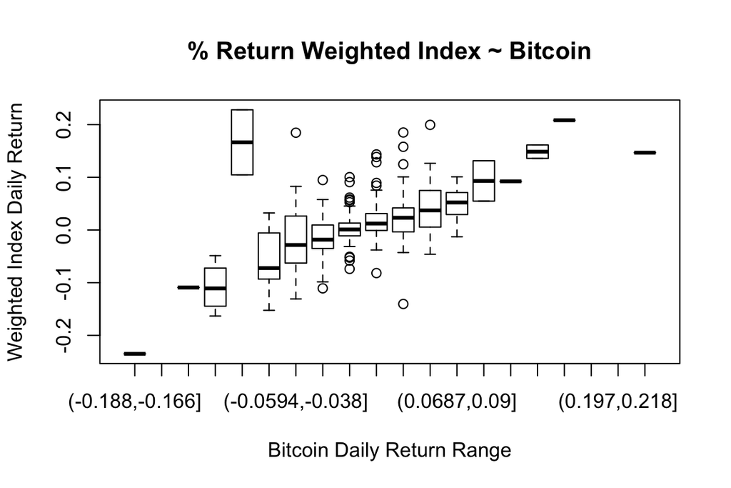